# Visualizing the dental workforce of OECD countries I

Sergio Uribe

2018-03-08

The Organisation for Economic Co-operation and Development host a [database](https://data.oecd.org/) with extensive data. In this post we will some visualizations to compare the number of dentists in each country.

Packages used:

- tidyverse
- gghighlight
- kableExtra

First we load the data. Now there is a package ([OECD](https://cran.r-project.org/web/packages/OECD/index.html)) able to extract the datasets, but I will use a local copy:

```r
dent_oecd <- read_csv("https://docs.google.com/spreadsheets/d/e/2PACX-1vStv7Pr69DtRKv6Nw6gVBep8hbT3pEeO6B1vNwxK_1DUHgpoTgbuRpZ4SvgtHFQnBZJVGeeQVyRuXZl/pub?gid=1330297229&single=true&output=csv")
```

Always is preferable to take a look the data and its structure:

```r
head(dent_oecd)
```

```
## # A tibble: 6 x 11
##   VAR     Variable        UNIT    Measure COU   Country    YEA  Year Value
##   <chr>   <chr>           <chr>   <chr>   <chr> <chr>    <int> <int> <dbl>
## 1 HEDUDN… Dentists gradu… NOMBRE… Number  AUS   Austral…  2008  2008  552.
## 2 HEDUDN… Dentists gradu… NOMBRE… Number  AUS   Austral…  2009  2009  632.
## 3 HEDUDN… Dentists gradu… NOMBRE… Number  AUS   Austral…  2010  2010  665.
## 4 HEDUDN… Dentists gradu… NOMBRE… Number  AUS   Austral…  2011  2011  684.
## 5 HEDUDN… Dentists gradu… NOMBRE… Number  AUS   Austral…  2012  2012  723.
## 6 HEDUDN… Dentists gradu… NOMBRE… Number  AUS   Austral…  2013  2013  894.
## # ... with 2 more variables: `Flag Codes` <chr>, Flags <chr>
```

```r
glimpse(dent_oecd)
```

```
## Observations: 956
## Variables: 11
## $ VAR          <chr> "HEDUDNGR", "HEDUDNGR", "HEDUDNGR", "HEDUDNGR", "...
## $ Variable     <chr> "Dentists graduates", "Dentists graduates", "Dent...
## $ UNIT         <chr> "NOMBRENB", "NOMBRENB", "NOMBRENB", "NOMBRENB", "...
## $ Measure      <chr> "Number", "Number", "Number", "Number", "Number",...
## $ COU          <chr> "AUS", "AUS", "AUS", "AUS", "AUS", "AUS", "AUS", ...
## $ Country      <chr> "Australia", "Australia", "Australia", "Australia...
## $ YEA          <int> 2008, 2009, 2010, 2011, 2012, 2013, 2014, 2015, 2...
## $ Year         <int> 2008, 2009, 2010, 2011, 2012, 2013, 2014, 2015, 2...
## $ Value        <dbl> 552, 632, 665, 684, 723, 894, 861, 957, 118, 134,...
## $ `Flag Codes` <chr> NA, NA, NA, NA, NA, NA, NA, NA, NA, NA, NA, NA, N...
## $ Flags        <chr> NA, NA, NA, NA, NA, NA, NA, NA, NA, NA, NA, NA, N...
```

And a summary:

```r
summary(dent_oecd)
```

```
##      VAR              Variable             UNIT
##  Length:956         Length:956         Length:956
##  Class :character   Class :character   Class :character
##  Mode  :character   Mode  :character   Mode  :character
##
##
##
##    Measure              COU              Country               YEA
##  Length:956         Length:956         Length:956         Min.   :2008
##  Class :character   Class :character   Class :character   1st Qu.:2010
##  Mode  :character   Mode  :character   Mode  :character   Median :2012
##                                                           Mean   :2012
##                                                           3rd Qu.:2014
##                                                           Max.   :2016
##       Year          Value            Flag Codes           Flags
##  Min.   :2008   Min.   :     0.00   Length:956         Length:956
##  1st Qu.:2010   1st Qu.:     1.34   Class :character   Class :character
##  Median :2012   Median :     6.00   Mode  :character   Mode  :character
##  Mean   :2012   Mean   :  3064.18
##  3rd Qu.:2014   3rd Qu.:  1071.00
##  Max.   :2016   Max.   :100994.00
```

I will use the `Dentists graduates`, and `Per 100 000 population` so let’s filter and replace the former data set

```r
dent_oecd <- dent_oecd %>%
  filter(Variable == "Dentists graduates",
         Measure == "Per 100 000 population")
```

Let’s plot. Since is a temporal trend, a line plot could be a good idea:

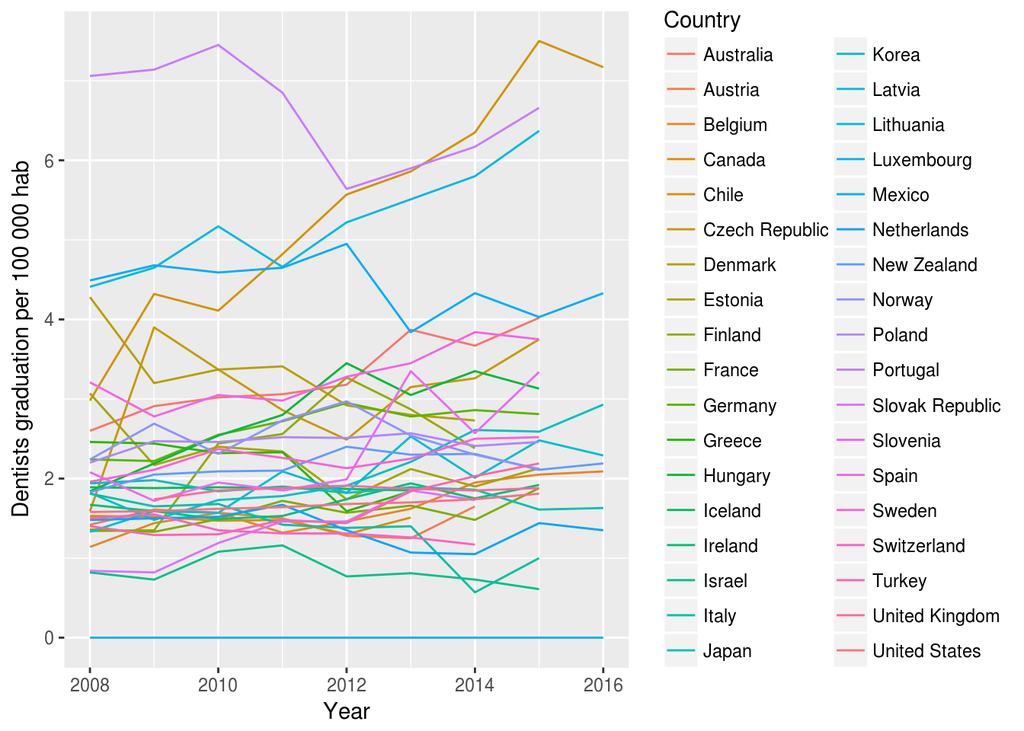

```r
dent_oecd %>%  # this means: take the dent_oecd dataframe, and
  ggplot(aes(x = Year, y = Value, color = Country)) + #plot the year in the X axis, the value in the y axis and color the lines per country
  geom_line() +
  labs(y = "Dentists graduation per 100 000 hab")
```

Hmmm….the problem here is that isn’t easy to differentiate the countries.

We have to choices: 1. plot each country separate, or 2. highlight one or few countries from the group we can use the package

## 1. Plotting one graph per country: faceting.

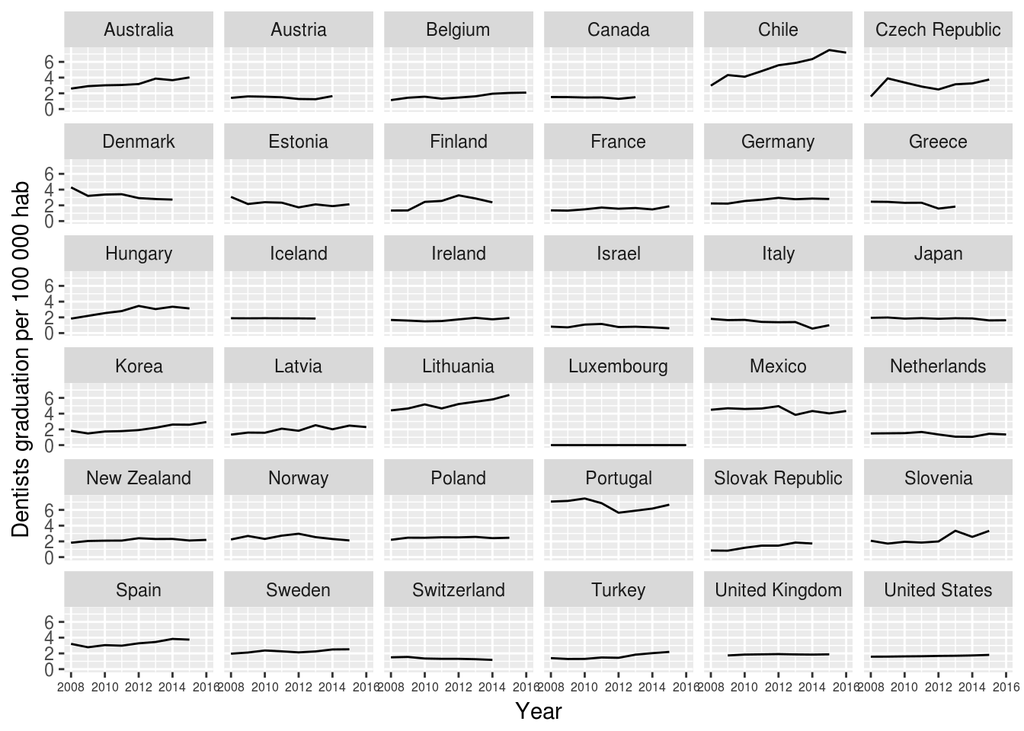

```r
dent_oecd  %>%
    ggplot(aes(x = Year, y = Value)) + # we delete the color = Country, since is not necessary
  geom_line() +
  facet_wrap(~Country) + #this means: plot separately each country
  theme(axis.text.x = element_text(colour="grey20",size=6)) +
  labs(y = "Dentists graduation per 100 000 hab")
```

*TODO: learn how to order the plots, e.g. from higher rate to lower*

We can transform the Value var using the log10. With `ggplot2` we can directly add the transformation to any axis, as y-axis in this case. We use `scale_y_log10()`. Sometimes is worth to use to expand some small differences or to graph data with orders of magnitude of difference.

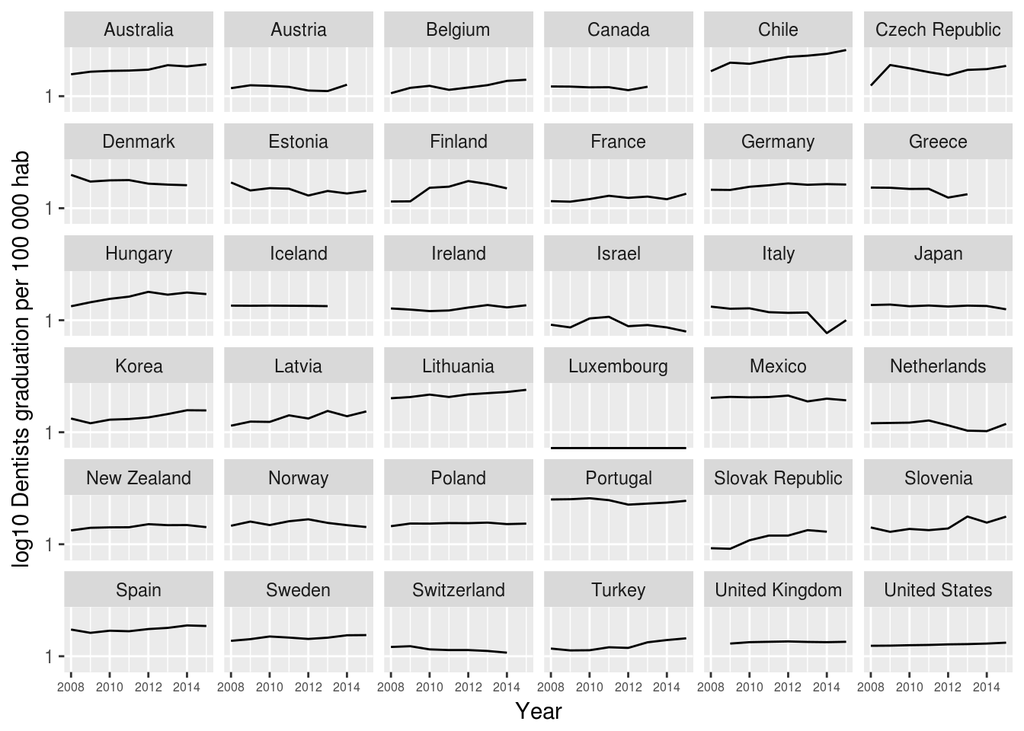

```r
dent_oecd  %>%
  filter(Year < 2016) %>%
    ggplot(aes(x = Year, y = Value)) +
  geom_line() +
  facet_wrap(~Country) +
  theme(axis.text.x = element_text(size=6)) +
  labs(y = "log10 Dentists graduation per 100 000 hab") +
  scale_y_log10()
```

## 2. Using `gghighlight`

`gghighlight` is a package that highlight ggplot’s Lines and Points with Predicates

Remember the first graph:

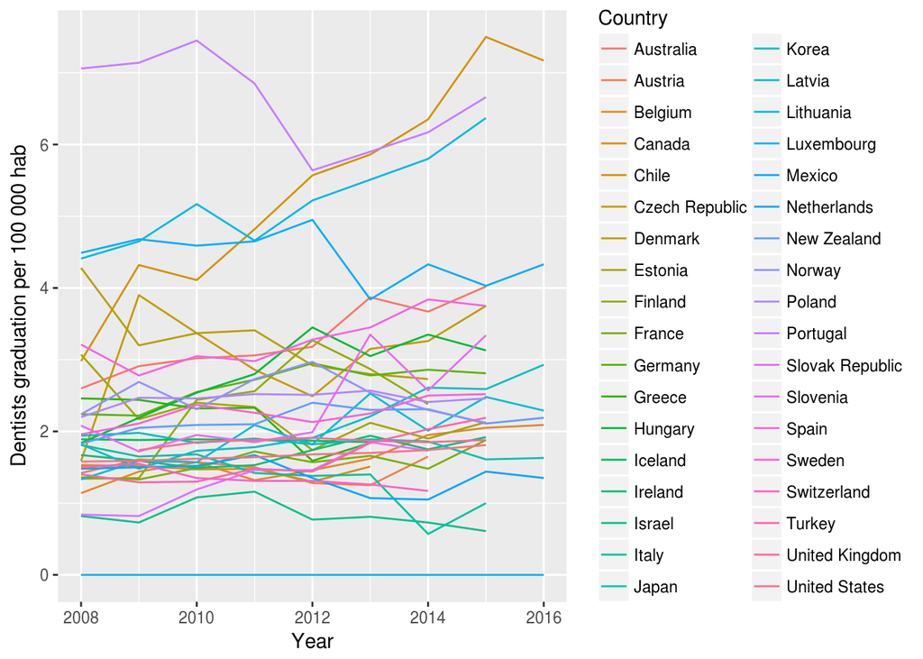

```r
dent_oecd %>%
  ggplot(aes(x = Year, y = Value, color = Country)) +
  geom_line() +
  labs(y = "Dentists graduation per 100 000 hab")
```

With gghighlight we can, as the name implies, highlight some lines according to a criteria or predicate.

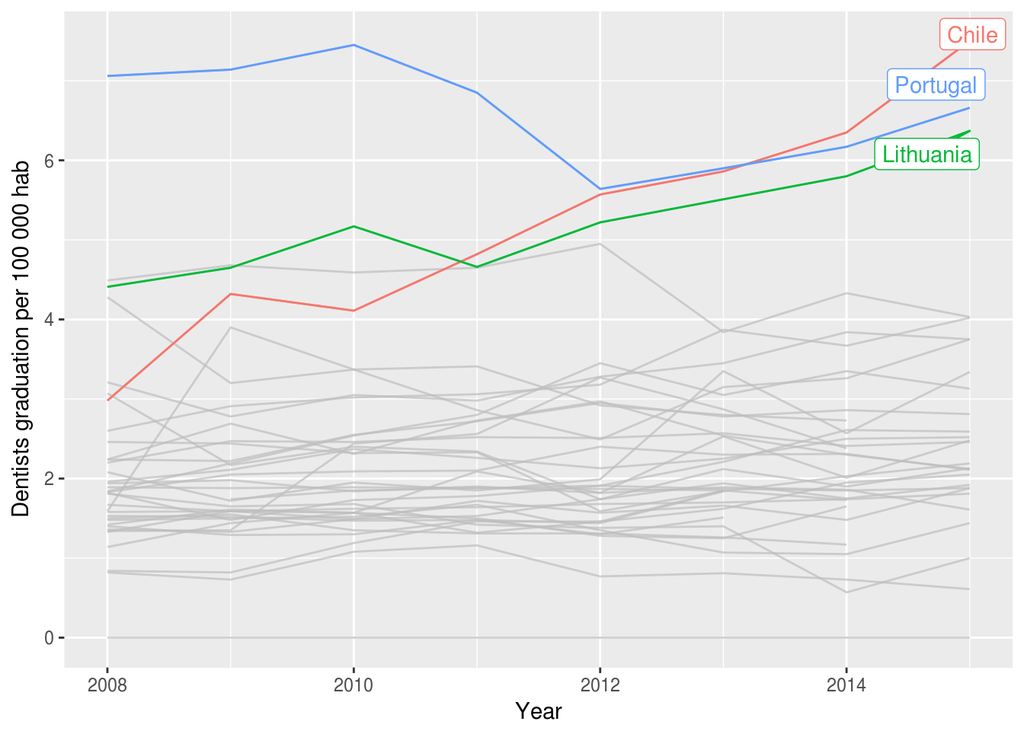

```r
dent_oecd %>%
  filter(Year < 2016) %>%
  gghighlight_line(aes(x = Year, y = Value, color = Country),
                   predicate = mean(Value) > 5) + # this is the threshold
  labs(y = "Dentists graduation per 100 000 hab")
```

```r
dent_oecd %>%
  group_by(Year) %>%
  summarise(averageOECD = mean(Value)) %>%
  spread(Year, averageOECD)
```

```
## # A tibble: 1 x 9
##   `2008` `2009` `2010` `2011` `2012` `2013` `2014` `2015` `2016`
##    <dbl>  <dbl>  <dbl>  <dbl>  <dbl>  <dbl>  <dbl>  <dbl>  <dbl>
## 1   2.15   2.23   2.33   2.35   2.34   2.45   2.51   2.79   2.66
```

And a pivot table in the `dplyr` way

```r
dent_oecd %>%
  group_by(Country, Year) %>%
  summarise(average = mean(Value)) %>%
  spread(Year, average)
```

```
## # A tibble: 36 x 10
## # Groups:   Country [36]
##    Country  `2008` `2009` `2010` `2011` `2012` `2013` `2014` `2015` `2016`
##    <chr>     <dbl>  <dbl>  <dbl>  <dbl>  <dbl>  <dbl>  <dbl>  <dbl>  <dbl>
##  1 Austral…   2.60   2.91   3.02   3.06   3.18   3.87   3.67   4.02  NA
##  2 Austria    1.42   1.61   1.57   1.50   1.28   1.25   1.65  NA     NA
##  3 Belgium    1.14   1.44   1.57   1.32   1.46   1.62   1.95   2.05   2.09
##  4 Canada     1.53   1.52   1.47   1.48   1.30   1.51  NA     NA     NA
##  5 Chile      2.98   4.32   4.11   4.82   5.57   5.86   6.35   7.50   7.17
##  6 Czech R…   1.59   3.90   3.37   2.86   2.49   3.15   3.26   3.75  NA
##  7 Denmark    4.28   3.20   3.37   3.41   2.92   2.80   2.73  NA     NA
##  8 Estonia    3.07   2.17   2.40   2.34   1.74   2.12   1.90   2.13  NA
##  9 Finland    1.34   1.35   2.44   2.56   3.27   2.87   2.38  NA     NA
## 10 France     1.36   1.33   1.49   1.72   1.57   1.66   1.48   1.88  NA
## # ... with 26 more rows
```

Now enhance the table with the package `kableExtra`:

`install.packages("kableExtra")`

`library(kableExtra)`

First I create the table and store as an object called `table_dent`

```r
table_dent <- dent_oecd %>%
  group_by(Country, Year) %>%
  summarise(average = mean(Value)) %>%
  spread(Year, average)
```

then apply the `kable` enhance to the object `table_dent` to show a nice formatted table:

```r
knitr::kable(table_dent,
             caption = "Dentists graduating per 100 000 habs. OECD countries")
```

Dentists graduating per 100 000 habs. OECD countries

| Country | 2008 | 2009 | 2010 | 2011 | 2012 | 2013 | 2014 | 2015 | 2016 |
| --- | --- | --- | --- | --- | --- | --- | --- | --- | --- |
| Australia | 2.60 | 2.91 | 3.02 | 3.06 | 3.18 | 3.87 | 3.67 | 4.02 | NA |
| Austria | 1.42 | 1.61 | 1.57 | 1.50 | 1.28 | 1.25 | 1.65 | NA | NA |
| Belgium | 1.14 | 1.44 | 1.57 | 1.32 | 1.46 | 1.62 | 1.95 | 2.05 | 2.09 |
| Canada | 1.53 | 1.52 | 1.47 | 1.48 | 1.30 | 1.51 | NA | NA | NA |
| Chile | 2.98 | 4.32 | 4.11 | 4.82 | 5.57 | 5.86 | 6.35 | 7.50 | 7.17 |
| Czech Republic | 1.59 | 3.90 | 3.37 | 2.86 | 2.49 | 3.15 | 3.26 | 3.75 | NA |
| Denmark | 4.28 | 3.20 | 3.37 | 3.41 | 2.92 | 2.80 | 2.73 | NA | NA |
| Estonia | 3.07 | 2.17 | 2.40 | 2.34 | 1.74 | 2.12 | 1.90 | 2.13 | NA |
| Finland | 1.34 | 1.35 | 2.44 | 2.56 | 3.27 | 2.87 | 2.38 | NA | NA |
| France | 1.36 | 1.33 | 1.49 | 1.72 | 1.57 | 1.66 | 1.48 | 1.88 | NA |
| Germany | 2.24 | 2.22 | 2.55 | 2.72 | 2.95 | 2.78 | 2.86 | 2.81 | NA |
| Greece | 2.46 | 2.44 | 2.32 | 2.33 | 1.59 | 1.84 | NA | NA | NA |
| Hungary | 1.84 | 2.19 | 2.54 | 2.80 | 3.45 | 3.05 | 3.35 | 3.13 | NA |
| Iceland | 1.89 | 1.88 | 1.89 | 1.88 | 1.87 | 1.85 | NA | NA | NA |
| Ireland | 1.67 | 1.59 | 1.49 | 1.53 | 1.74 | 1.94 | 1.75 | 1.92 | NA |
| Israel | 0.82 | 0.73 | 1.08 | 1.16 | 0.77 | 0.81 | 0.73 | 0.61 | NA |
| Italy | 1.81 | 1.65 | 1.68 | 1.42 | 1.38 | 1.40 | 0.57 | 1.00 | NA |
| Japan | 1.94 | 1.98 | 1.84 | 1.90 | 1.82 | 1.89 | 1.86 | 1.61 | 1.63 |
| Korea | 1.82 | 1.48 | 1.73 | 1.78 | 1.91 | 2.21 | 2.61 | 2.59 | 2.93 |
| Latvia | 1.33 | 1.59 | 1.57 | 2.09 | 1.82 | 2.53 | 2.01 | 2.48 | 2.29 |
| Lithuania | 4.41 | 4.65 | 5.17 | 4.66 | 5.22 | 5.51 | 5.80 | 6.37 | NA |
| Luxembourg | 0.00 | 0.00 | 0.00 | 0.00 | 0.00 | 0.00 | 0.00 | 0.00 | 0.00 |
| Mexico | 4.49 | 4.68 | 4.59 | 4.65 | 4.95 | 3.84 | 4.33 | 4.03 | 4.33 |
| Netherlands | 1.48 | 1.50 | 1.52 | 1.67 | 1.35 | 1.07 | 1.05 | 1.44 | 1.35 |
| New Zealand | 1.83 | 2.05 | 2.09 | 2.10 | 2.40 | 2.30 | 2.31 | 2.11 | 2.19 |
| Norway | 2.24 | 2.69 | 2.31 | 2.73 | 2.97 | 2.54 | 2.30 | 2.12 | NA |
| Poland | 2.20 | 2.47 | 2.46 | 2.52 | 2.51 | 2.57 | 2.41 | 2.46 | NA |
| Portugal | 7.06 | 7.14 | 7.45 | 6.85 | 5.64 | 5.90 | 6.17 | 6.66 | NA |
| Slovak Republic | 0.84 | 0.82 | 1.19 | 1.46 | 1.46 | 1.85 | 1.73 | NA | NA |
| Slovenia | 2.08 | 1.72 | 1.95 | 1.85 | 1.99 | 3.35 | 2.57 | 3.34 | NA |
| Spain | 3.21 | 2.78 | 3.05 | 2.98 | 3.28 | 3.45 | 3.84 | 3.75 | NA |
| Sweden | 1.96 | 2.11 | 2.37 | 2.26 | 2.13 | 2.25 | 2.50 | 2.52 | NA |
| Switzerland | 1.50 | 1.55 | 1.35 | 1.31 | 1.31 | 1.26 | 1.17 | NA | NA |
| Turkey | 1.40 | 1.29 | 1.30 | 1.48 | 1.44 | 1.84 | 2.03 | 2.19 | NA |
| United Kingdom | NA | 1.74 | 1.85 | 1.88 | 1.91 | 1.87 | 1.85 | 1.88 | NA |
| United States | 1.58 | 1.59 | 1.62 | 1.64 | 1.68 | 1.70 | 1.74 | 1.81 | NA |

More information about ggplot2

- [ggplot2 cheat sheet](https://www.rstudio.com/wp-content/uploads/2015/03/ggplot2-cheatsheet.pdf)
- [ggplot2 Search by task](https://www.computerworld.com/article/2935394/business-intelligence/my-ggplot2-cheat-sheet-search-by-task.html)
- [ggplot 2 reference manual](http://ggplot2.tidyverse.org/reference/)